# Machine Learning with GeoMx

Nayana Yeshlur

### Load Libraries

```r
library(NanoStringNCTools)
library(GeomxTools)
library(GeoMxWorkflows)
library(data.table)
```

## **Overview**

This vignette demonstrates the use of GeoMx gene expression data in machine learning models.

### Loading Data

The dataset used in this guide is a GeoMx kidney dataset created with the WTA assay. The gene expression data from this dataset will be used for supervised binary classification of diabetic kidney disease (DKD) and normal samples.

```r
target_demoData <- readRDS("target_demoData.rds")
```

#### Dimensions of Data

```
#> Features  Samples
#>    10131      221
```

#### Sankey Diagram of Kidney Dataset

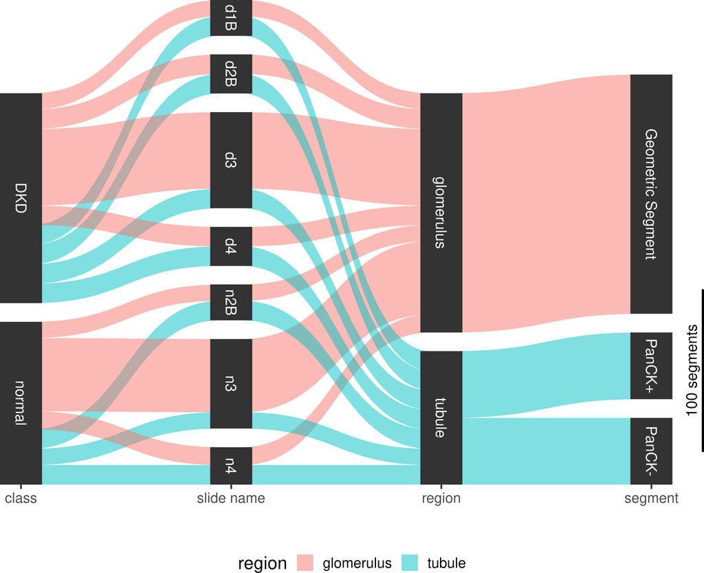

## **Data Pre-processing**

#### The data has already undergone QC and Normalization.

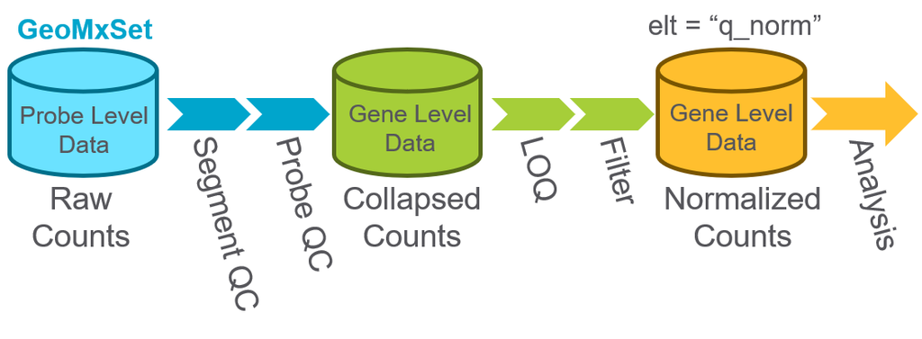

### Subsetting target_demoData by region

This dataset is subset by region to account for region-specific effects on gene expression. Going forward, the Glomerulus region subset will be utilized.

```r
# subsetting target_demoData by region
glomerulus_region_subset <-
  subset(target_demoData,
         select=pData(target_demoData)[["region"]]=="glomerulus")

tubule_region_subset <-
  subset(target_demoData,
         select=pData(target_demoData)[["region"]]=="tubule")
```

### Count of DKD and normal samples in the Glomeruli

```r
table(glomerulus_region_subset$class)
```

```
#>
#>    DKD normal
#>     77     65
```

### **Data Splitting for Training and Testing of Models**

### Split Function

The splitgeomx function splits the GeoMxSet Object into two objects, one to be used for model training and one for model testing. Maintaining the split data as GeoMxSet Objects allows users to continue to be able to link experiment data with associated metadata. So each subset object contains the subset experiment data and all of the associated subset metadata.

```r
source("GeoMxSetSplit.R")

# It is common for the training and testing dataset split ratio to be 70/30 or 80/20.
split_ratio <- 0.7

train_test_list <- splitgeomx(glomerulus_region_subset,split_ratio)
train_split <- train_test_list[[1]]
test_split <- train_test_list[[2]]
```

#### Dimensions of the original GeoMxSet Object, subset by region

```
#> Features  Samples
#>    10131      142
```

#### Dimensions of the GeoMxSet Object for training

```
#> Features  Samples
#>    10131       99
```

#### Dimensions of the GeoMxSet Object for testing

```
#> Features  Samples
#>    10131       43
```

### Dataset Builder Function

The datasetBuilder function takes the output split objects from the splitgeomx function and creates training and testing data frames. The function combines transposed expression data with the class used for classification. The expression data consists of samples as rows and gene expression counts as columns.

```r
source("DatasetBuilder.R")
classifier_column <- "class" # For this dataset, the classification column is labeled as class
train_data <- datasetBuilder(exprs(train_split), pData(train_split)[[classifier_column]])
test_data <- datasetBuilder(exprs(test_split), pData(test_split)[[classifier_column]])
```

#### Dimensions of train_data

```
#> [1]    99 10132
```

#### First 5 rows and last 10 columns of train_data

|  | HLA.A | IGHA1 | IGHG1 | IGHG2 | IGHG3 | IGHG4 | IGHM | IGKC | IGLC1 | class |
| --- | --- | --- | --- | --- | --- | --- | --- | --- | --- | --- |
| DSP-1001250007851-H-C07.dcc | 132 | 16 | 56 | 45 | 53 | 143 | 15 | 42 | 56 | DKD |
| DSP-1001250007851-H-C02.dcc | 155 | 24 | 45 | 42 | 33 | 92 | 18 | 39 | 56 | DKD |
| DSP-1001250007864-D-D03.dcc | 234 | 15 | 22 | 19 | 23 | 33 | 9 | 24 | 24 | normal |
| DSP-1001250007851-H-D03.dcc | 163 | 20 | 28 | 32 | 38 | 75 | 17 | 33 | 52 | DKD |
| DSP-1001250007851-H-F03.dcc | 155 | 26 | 29 | 28 | 32 | 46 | 23 | 18 | 46 | DKD |

#### Dimensions of test_data

```
#> [1]    43 10132
```

#### First 5 rows and last 10 columns of test_data

|  | HLA.A | IGHA1 | IGHG1 | IGHG2 | IGHG3 | IGHG4 | IGHM | IGKC | IGLC1 | class |
| --- | --- | --- | --- | --- | --- | --- | --- | --- | --- | --- |
| DSP-1001250007851-H-A04.dcc | 216 | 26 | 71 | 54 | 44 | 104 | 20 | 77 | 83 | DKD |
| DSP-1001250007851-H-A05.dcc | 271 | 36 | 89 | 68 | 70 | 138 | 38 | 105 | 69 | DKD |
| DSP-1001250007851-H-A06.dcc | 398 | 30 | 87 | 85 | 64 | 118 | 31 | 100 | 85 | DKD |
| DSP-1001250007851-H-B01.dcc | 161 | 34 | 40 | 31 | 43 | 79 | 20 | 58 | 44 | DKD |
| DSP-1001250007851-H-B02.dcc | 171 | 45 | 39 | 44 | 39 | 101 | 17 | 92 | 56 | DKD |

## **Feature Selection**

### Identifying Genes with Highest Coefficient of Variation

```r
# create a log2 transform of the data for analysis
assayDataElement(object = glomerulus_region_subset, elt = "log_q") <-
  assayDataApply(glomerulus_region_subset, 2, FUN = log, base = 2, elt = "q_norm")

# create CV function
calc_CV <- function(x) {sd(x) / mean(x)}
CV_dat <- assayDataApply(glomerulus_region_subset,
                         elt = "log_q", MARGIN = 1, calc_CV)
# show the highest CD genes and their CV values
CV_dat_ordered <- sort(CV_dat, decreasing = TRUE)[1:20]

kable(CV_dat_ordered, col.names = c(), digits = 5,
      caption = "CV results",
      align = "lc", row.names = TRUE)
```

CV results

| CAMK2N1 | 0.53935 |
| --- | --- |
| REN | 0.43612 |
| AKR1C1 | 0.41890 |
| TSPY1 | 0.38752 |
| IGKC | 0.35871 |
| IGHG1 | 0.35119 |
| LCN2 | 0.34438 |
| RPS4Y1 | 0.33895 |
| ALDOB | 0.32786 |
| HSPA1B | 0.32281 |
| HBB | 0.32194 |
| PRY | 0.32190 |
| IGHG2 | 0.31839 |
| FGB | 0.30909 |
| SAA2 | 0.30536 |
| CCL23 | 0.30497 |
| HBA2 | 0.30208 |
| HSPA6 | 0.30048 |
| DEFA1B | 0.29449 |
| SERPINA3 | 0.29387 |

### Identifying Genes with Significant Differential Expression

```r
# convert test variables to factors
pData(target_demoData)$testClass <-
  factor(pData(target_demoData)$class, c("normal", "DKD"))
```

```r
# run LMM:
# formula follows conventions defined by the lme4 package
results2 <- c()
for(region in c("glomerulus", "tubule")) {
  ind <- pData(target_demoData)$region == region
  mixedOutmc <-
    mixedModelDE(target_demoData[, ind],
                 elt = "log_q",
                 modelFormula = ~ testClass + (1 | slide),
                 groupVar = "testClass",
                 nCores = parallel::detectCores(),
                 multiCore = FALSE)

  # format results as data.frame
  r_test <- do.call(rbind, mixedOutmc["lsmeans", ])
  tests <- rownames(r_test)
  r_test <- as.data.frame(r_test)
  r_test$Contrast <- tests

  # use lapply in case you have multiple levels of your test factor to
  # correctly associate gene name with it's row in the results table
  r_test$Gene <-
    unlist(lapply(colnames(mixedOutmc),
                  rep, nrow(mixedOutmc["lsmeans", ][[1]])))
  r_test$Subset <- region
  r_test$FDR <- p.adjust(r_test$`Pr(>|t|)`, method = "fdr")
  r_test <- r_test[, c("Gene", "Subset", "Contrast", "Estimate",
                       "Pr(>|t|)", "FDR")]
  results2 <- rbind(results2, r_test)
}
```

```r
results2_sorted <- results2[order(-abs(results2$Estimate)),]
results2_filtered <- results2_sorted[results2_sorted$FDR <= .05,]
results2_filtered <- results2_filtered[results2_filtered$Subset == "glomerulus",]

kable(results2_filtered[1:20,], digits = 5,
      caption = "DE results",
      align = "lc", row.names = FALSE)
```

DE results

| Gene | Subset | Contrast | Estimate | Pr(>\|t\|) | FDR |
| --- | --- | --- | --- | --- | --- |
| DEFA1B | glomerulus | normal - DKD | -1.44353 | 0e+00 | 0.00000 |
| MAL2 | glomerulus | normal - DKD | 1.19272 | 5e-04 | 0.04760 |
| STARD7 | glomerulus | normal - DKD | 0.76715 | 0e+00 | 0.00000 |
| LSP1 | glomerulus | normal - DKD | -0.75484 | 0e+00 | 0.00000 |
| GPR182 | glomerulus | normal - DKD | -0.73987 | 0e+00 | 0.00000 |
| DHX34 | glomerulus | normal - DKD | -0.69179 | 0e+00 | 0.00002 |
| PPP2CB | glomerulus | normal - DKD | 0.68272 | 0e+00 | 0.00000 |
| ADI1 | glomerulus | normal - DKD | 0.63061 | 0e+00 | 0.00000 |
| VCL | glomerulus | normal - DKD | 0.59902 | 0e+00 | 0.00000 |
| CYTIP | glomerulus | normal - DKD | -0.58699 | 0e+00 | 0.00000 |
| TNFRSF10C | glomerulus | normal - DKD | -0.56300 | 0e+00 | 0.00007 |
| TMEM98 | glomerulus | normal - DKD | 0.55644 | 0e+00 | 0.00000 |
| CHCHD2 | glomerulus | normal - DKD | 0.55616 | 0e+00 | 0.00000 |
| SERINC2 | glomerulus | normal - DKD | -0.54810 | 0e+00 | 0.00006 |
| SPATA31A6 | glomerulus | normal - DKD | -0.54406 | 0e+00 | 0.00000 |
| PFKFB3 | glomerulus | normal - DKD | -0.53457 | 0e+00 | 0.00010 |
| CD48 | glomerulus | normal - DKD | -0.51605 | 0e+00 | 0.00004 |
| CEACAM16 | glomerulus | normal - DKD | -0.51560 | 0e+00 | 0.00002 |
| KIDINS220 | glomerulus | normal - DKD | 0.51280 | 0e+00 | 0.00000 |
| SH2D3A | glomerulus | normal - DKD | -0.51040 | 0e+00 | 0.00043 |

### Volcano Plot of Differential Expression Results

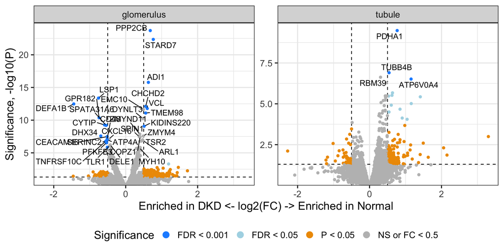

### Subsetting GeoMxSet Object by 20 genes of interest, as determined by DE

```r
DE_genes <- results2_filtered$Gene[1:20]
DE_subset <- subset(glomerulus_region_subset, TargetName %in% DE_genes)
```

### Subsetting GeoMxSet Object by 20 genes of interest, as determined by CV

```r
CV_genes <- names(CV_dat_ordered)
CV_subset <- subset(glomerulus_region_subset, TargetName %in% CV_genes)
```

## **Building Machine Learning Models**

### Input Parameters for ML Functions

#### 1. NanoStringGeoMxSet Object

#### 2. Classification Class

#### 3. Model Type

#### 4. Split Ratio (optional)

#### 6. Model Specific Parameters: Resampling Method (tuneLength, trainControl, tuneGrid) (optional)

### Model Outputs

#### 1. Results of Parameter Tuning

#### 2. Most Important Variables

#### 3. Results of Testing Model

### Available Models

#### **1. Naive Bayes (nb)**

##### Naive Bayes Classifier is a probabilistic classifier that assumes conditional independence between features. This model assumes a Gaussian distribution of data.

##### Parameters:

##### a. Laplace Correction (laplace)

##### b. Distribution Type (usekernel)

##### c. Bandwidth Adjustment (adjust)

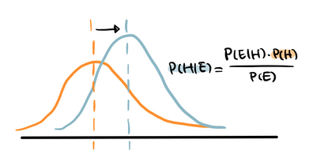

#### **2. K-Nearest Neighbor (knn)**

##### K-Nearest Neighbor Classifier is a non-parametric model that determines class membership (label) based on the most common label amongst k nearest neighbors.

##### Parameters:

##### a. Number of Neighbors (k)

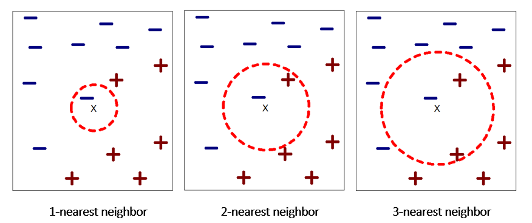

#### **3. Random Forest (rf)**

##### Random Forest Classifier is an ensemble learning method. The outputs of many decision trees, which are trained on a random sampling of data, are aggregated to a single final decision.

##### Parameters:

##### a. Number of Randomly Selected Predictors (mtry)

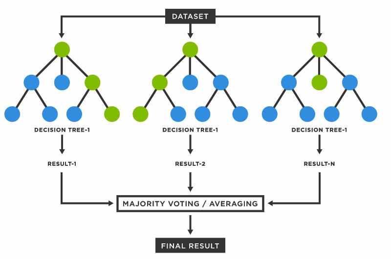

#### **4. Support Vector Machine (svm)**

##### Support Vector Machine Classifier is a non-probabilistic binary linear model. SVM aims to classify data based on the position in relation to a border or hyperplance between the positive and negative class. The border is determined to maximize the distance between the classes.

##### Parameters:

##### c. Class Weight (weight)

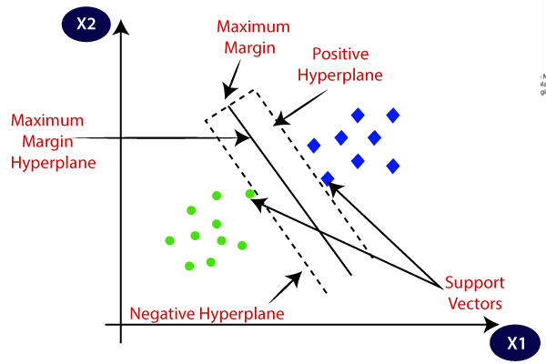

```r
source("MLFunctions.R")
```

## Naive Bayes

```r
ml_function(glomerulus_region_subset,"class", "nb")
```

```
#> Naive Bayes
#>
#>    99 samples
#> 10131 predictors
#>     2 classes: 'DKD', 'normal'
#>
#> No pre-processing
#> Resampling: Cross-Validated (10 fold)
#> Summary of sample sizes: 89, 88, 89, 89, 89, 90, ...
#> Resampling results across tuning parameters:
#>
#>   usekernel  Accuracy   Kappa
#>   FALSE      0.8278788  0.6557433
#>    TRUE      0.6690909  0.3541827
#>
#> Tuning parameter 'laplace' was held constant at a value of 0
#> Tuning
#>  parameter 'adjust' was held constant at a value of 1
#> Accuracy was used to select the optimal model using the largest value.
#> The final values used for the model were laplace = 0, usekernel = FALSE
#>  and adjust = 1.
#> ROC curve variable importance
#>
#>   only 20 most important variables shown (out of 10131)
#>
#>         Importance
#> MME         0.9563
#> DSTN        0.9555
#> NEDD9       0.9518
#> CDKN1C      0.9505
#> PCOLCE2     0.9482
#> MAL2        0.9444
#> ALDOB       0.9384
#> VEGFA       0.9363
#> EPAS1       0.9353
#> AIF1        0.9290
#> MPP5        0.9265
#> DCN         0.9248
#> GATM        0.9246
#> TSC22D3     0.9208
```

[output cut: 18 more lines]

```
#>                   Kappa : 0.6309
#>
#>  Mcnemar's Test P-Value : 0.2888444
#>
#>             Sensitivity : 0.9000
#>             Specificity : 0.7391
#>          Pos Pred Value : 0.7500
#>          Neg Pred Value : 0.8947
#>              Prevalence : 0.4651
#>          Detection Rate : 0.4186
#>    Detection Prevalence : 0.5581
#>       Balanced Accuracy : 0.8196
#>
#>        'Positive' Class : DKD
#>
```

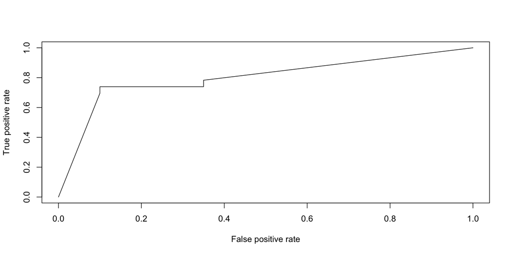

```
#> [1] "AUC"
#> [1] 0.798913
```

## K-Nearest Neighbor

```r
ml_function(glomerulus_region_subset,"class", "knn")
```

```
#> k-Nearest Neighbors
#>
#>    99 samples
#> 10131 predictors
#>     2 classes: 'DKD', 'normal'
#>
#> No pre-processing
#> Resampling: Cross-Validated (10 fold)
#> Summary of sample sizes: 90, 89, 89, 88, 90, 88, ...
#> Resampling results across tuning parameters:
#>
#>   k   Accuracy   Kappa
#>    3  0.9697980  0.9394047
#>    4  0.9688889  0.9345705
#>    5  0.9307071  0.8573548
#>    6  0.9207071  0.8338041
#>    7  0.8984848  0.7876503
#>    8  0.8984848  0.7928677
#>    9  0.8895960  0.7709446
#>   10  0.8805051  0.7516576
#>
#> Accuracy was used to select the optimal model using the largest value.
#> The final value used for the model was k = 3.
#> ROC curve variable importance
#>
#>   only 20 most important variables shown (out of 10131)
#>
#>         Importance
#> ALDOB       0.9294
#> DSTN        0.9140
#> NEDD9       0.9078
#> MAL2        0.9070
#> CDKN1C      0.9010
#> FXYD2       0.9005
#> PCOLCE2     0.8964
#> EPAS1       0.8935
#> MME         0.8935
#> GATM        0.8850
#> NDNF        0.8785
#> NDRG1       0.8783
```

[output cut: 20 more lines]

```
#>                   Kappa : 0.9534
#>
#>  Mcnemar's Test P-Value : 1
#>
#>             Sensitivity : 0.9524
#>             Specificity : 1.0000
#>          Pos Pred Value : 1.0000
#>          Neg Pred Value : 0.9565
#>              Prevalence : 0.4884
#>          Detection Rate : 0.4651
#>    Detection Prevalence : 0.4651
#>       Balanced Accuracy : 0.9762
#>
#>        'Positive' Class : DKD
#>
```

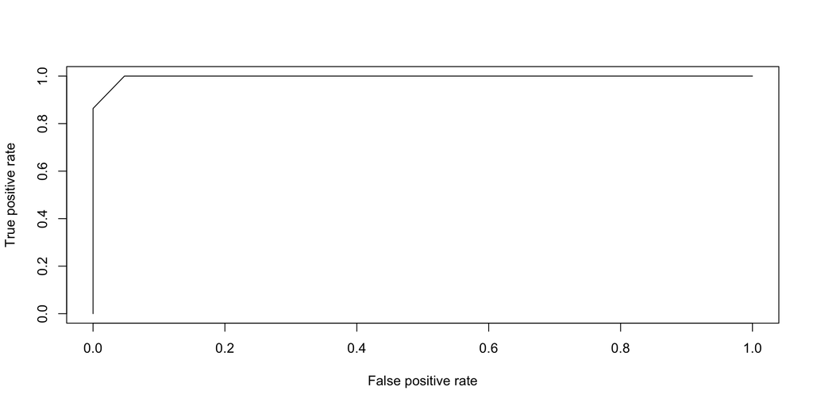

```
#> [1] "AUC"
#> [1] 0.9967532
```

## Random Forest

```r
ml_function(glomerulus_region_subset, "class", "rf")
```

```
#> Random Forest
#>
#>    99 samples
#> 10131 predictors
#>     2 classes: 'DKD', 'normal'
#>
#> No pre-processing
#> Resampling: Cross-Validated (10 fold)
#> Summary of sample sizes: 89, 89, 90, 89, 89, 89, ...
#> Resampling results across tuning parameters:
#>
#>   mtry   Accuracy   Kappa
#>       2  0.9095960  0.8135626
#>      16  0.9477778  0.8932327
#>     142  0.9688889  0.9369231
#>    1200  0.9688889  0.9369231
#>   10131  0.9395960  0.8795161
#>
#> Accuracy was used to select the optimal model using the largest value.
#> The final value used for the model was mtry = 142.
#> ROC curve variable importance
#>
#>   only 20 most important variables shown (out of 10131)
#>
#>          Importance
#> MAL2         0.9504
#> MME          0.9456
#> DSTN         0.9435
#> NEDD9        0.9423
#> CDKN1C       0.9331
#> ALDOB        0.9319
#> EPAS1        0.9230
#> GATM         0.9176
#> PCOLCE2      0.9172
#> NDNF         0.9147
#> MPP5         0.9145
#> FXYD2        0.9138
#> AIF1         0.9097
#> NEBL         0.9049
#> DCN          0.9039
```

[output cut: 17 more lines]

```
#>                   Kappa : 0.8147
#>
#>  Mcnemar's Test P-Value : 0.1336
#>
#>             Sensitivity : 1.0000
#>             Specificity : 0.8182
#>          Pos Pred Value : 0.8400
#>          Neg Pred Value : 1.0000
#>              Prevalence : 0.4884
#>          Detection Rate : 0.4884
#>    Detection Prevalence : 0.5814
#>       Balanced Accuracy : 0.9091
#>
#>        'Positive' Class : DKD
#>
```

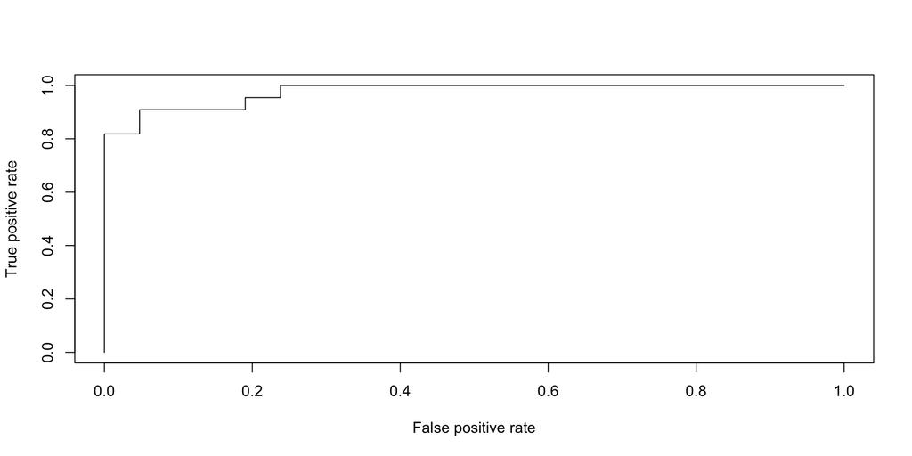

```
#> [1] "AUC"
#> [1] 0.9761905
```

## Support Vector Machine

```r
ml_function(glomerulus_region_subset,"class", "svm")
```

```
#> L2 Regularized Linear Support Vector Machines with Class Weights
#>
#>    99 samples
#> 10131 predictors
#>     2 classes: 'DKD', 'normal'
#>
#> No pre-processing
#> Resampling: Cross-Validated (10 fold)
#> Summary of sample sizes: 89, 90, 88, 90, 90, 89, ...
#> Resampling results across tuning parameters:
#>
#>   cost  Loss  weight  Accuracy   Kappa
#>   0.25  L1    1       0.9900000  0.9782609
#>   0.25  L1    2       0.9900000  0.9782609
#>   0.25  L1    3       0.9900000  0.9782609
#>   0.25  L2    1       0.9688889  0.9334448
#>   0.25  L2    2       0.9900000  0.9782609
#>   0.25  L2    3       0.9900000  0.9782609
#>   0.50  L1    1       0.9900000  0.9782609
#>   0.50  L1    2       0.9900000  0.9782609
#>   0.50  L1    3       0.9900000  0.9782609
#>   0.50  L2    1       0.9688889  0.9334448
#>   0.50  L2    2       0.9900000  0.9782609
#>   0.50  L2    3       0.9900000  0.9782609
#>   1.00  L1    1       0.9900000  0.9782609
#>   1.00  L1    2       0.9900000  0.9782609
#>   1.00  L1    3       0.9900000  0.9782609
#>   1.00  L2    1       0.9688889  0.9334448
#>   1.00  L2    2       0.9900000  0.9782609
#>   1.00  L2    3       0.9900000  0.9782609
#>
#> Accuracy was used to select the optimal model using the largest value.
#> The final values used for the model were cost = 0.25, Loss = L1 and weight = 1.
#> ROC curve variable importance
#>
#>   only 20 most important variables shown (out of 10131)
#>
#>         Importance
#> ALDOB       0.9487
#> FXYD2       0.9338
```

[output cut: 30 more lines]

```
#>                   Kappa : 0.9067
#>
#>  Mcnemar's Test P-Value : 0.4795
#>
#>             Sensitivity : 0.9048
#>             Specificity : 1.0000
#>          Pos Pred Value : 1.0000
#>          Neg Pred Value : 0.9167
#>              Prevalence : 0.4884
#>          Detection Rate : 0.4419
#>    Detection Prevalence : 0.4419
#>       Balanced Accuracy : 0.9524
#>
#>        'Positive' Class : DKD
#>
```

## Naive Bayes, Utilizing CV Results for Feature Selection

```r
ml_function(CV_subset,"class", "nb")
```

```
#> Naive Bayes
#>
#> 99 samples
#> 20 predictors
#>  2 classes: 'DKD', 'normal'
#>
#> No pre-processing
#> Resampling: Cross-Validated (10 fold)
#> Summary of sample sizes: 89, 89, 89, 89, 89, 88, ...
#> Resampling results across tuning parameters:
#>
#>   usekernel  Accuracy   Kappa
#>   FALSE      0.8695960  0.7387371
#>    TRUE      0.7805051  0.5644548
#>
#> Tuning parameter 'laplace' was held constant at a value of 0
#> Tuning
#>  parameter 'adjust' was held constant at a value of 1
#> Accuracy was used to select the optimal model using the largest value.
#> The final values used for the model were laplace = 0, usekernel = FALSE
#>  and adjust = 1.
#> ROC curve variable importance
#>
#>          Importance
#> ALDOB        0.9379
#> TSPY1        0.8511
#> DEFA1B       0.8302
#> PRY          0.8185
#> IGHG2        0.8013
#> IGKC         0.7943
#> RPS4Y1       0.7801
#> IGHG1        0.7732
#> HSPA1B       0.6850
#> CCL23        0.6068
#> HSPA6        0.5898
#> SERPINA3     0.5888
#> FGB          0.5703
#> LCN2         0.5654
#> AKR1C1       0.5560
#> HBA2         0.5558
```

[output cut: 16 more lines]

```
#>                   Kappa : 0.5483
#>
#>  Mcnemar's Test P-Value : 0.026857
#>
#>             Sensitivity : 0.6250
#>             Specificity : 0.9474
#>          Pos Pred Value : 0.9375
#>          Neg Pred Value : 0.6667
#>              Prevalence : 0.5581
#>          Detection Rate : 0.3488
#>    Detection Prevalence : 0.3721
#>       Balanced Accuracy : 0.7862
#>
#>        'Positive' Class : DKD
#>
```

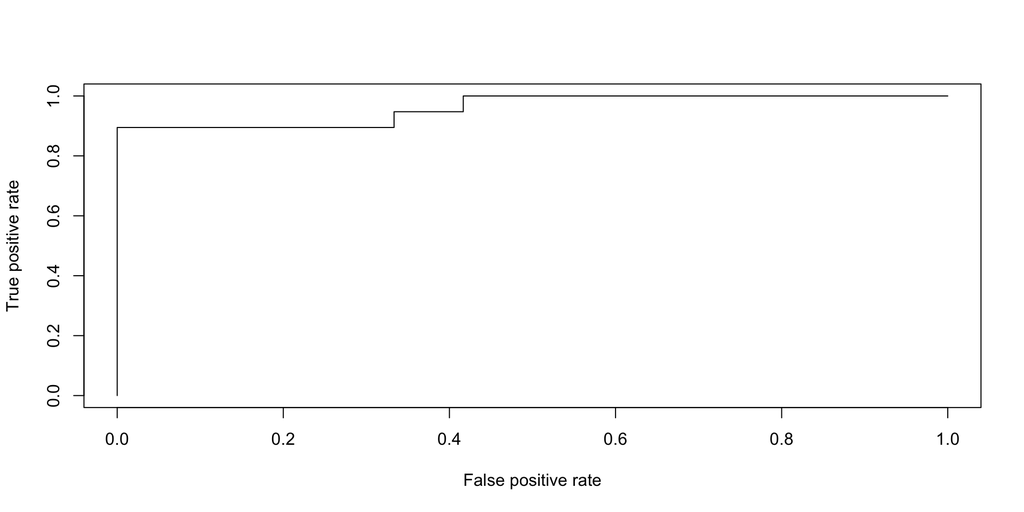

```
#> [1] "AUC"
#> [1] 0.9605263
```

## K-Nearest Neighbor, Utilizing CV Results for Feature Selection

```r
ml_function(CV_subset,"class", "knn")
```

```
#> k-Nearest Neighbors
#>
#> 99 samples
#> 20 predictors
#>  2 classes: 'DKD', 'normal'
#>
#> No pre-processing
#> Resampling: Cross-Validated (10 fold)
#> Summary of sample sizes: 89, 89, 90, 88, 89, 89, ...
#> Resampling results across tuning parameters:
#>
#>   k   Accuracy   Kappa
#>    3  0.8473737  0.6933333
#>    4  0.8364646  0.6713559
#>    5  0.8675758  0.7344047
#>    6  0.8475758  0.6944047
#>    7  0.8575758  0.7144047
#>    8  0.8273737  0.6520690
#>    9  0.8464646  0.6913559
#>   10  0.8484848  0.6951177
#>
#> Accuracy was used to select the optimal model using the largest value.
#> The final value used for the model was k = 5.
#> ROC curve variable importance
#>
#>          Importance
#> ALDOB        0.9338
#> TSPY1        0.7857
#> RPS4Y1       0.7690
#> IGHG2        0.7343
#> DEFA1B       0.7300
#> HSPA1B       0.7230
#> IGHG1        0.7210
#> IGKC         0.7198
#> PRY          0.7177
#> HBA2         0.6299
#> HBB          0.5891
#> CCL23        0.5860
#> SERPINA3     0.5768
#> REN          0.5527
```

[output cut: 18 more lines]

```
#>                   Kappa : 0.8093
#>
#>  Mcnemar's Test P-Value : 0.6171
#>
#>             Sensitivity : 0.8846
#>             Specificity : 0.9412
#>          Pos Pred Value : 0.9583
#>          Neg Pred Value : 0.8421
#>              Prevalence : 0.6047
#>          Detection Rate : 0.5349
#>    Detection Prevalence : 0.5581
#>       Balanced Accuracy : 0.9129
#>
#>        'Positive' Class : DKD
#>
```

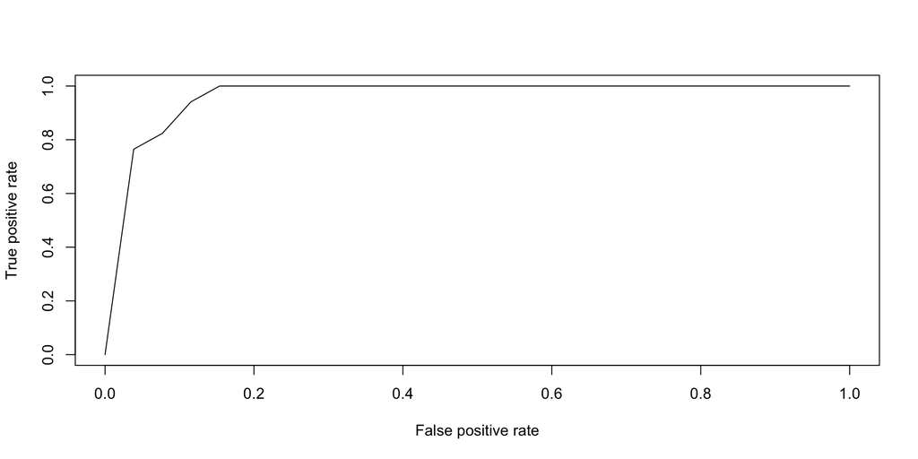

```
#> [1] "AUC"
#> [1] 0.9626697
```

## Random Forest, Utilizing CV Results for Feature Selection

```r
ml_function(CV_subset, "class", "rf")
```

```
#> Random Forest
#>
#> 99 samples
#> 20 predictors
#>  2 classes: 'DKD', 'normal'
#>
#> No pre-processing
#> Resampling: Cross-Validated (10 fold)
#> Summary of sample sizes: 89, 89, 89, 90, 89, 89, ...
#> Resampling results across tuning parameters:
#>
#>   mtry  Accuracy   Kappa
#>    2    0.9477778  0.8971429
#>    6    0.9388889  0.8763097
#>   11    0.9288889  0.8525942
#>   15    0.9188889  0.8325942
#>   20    0.9086869  0.8163256
#>
#> Accuracy was used to select the optimal model using the largest value.
#> The final value used for the model was mtry = 2.
#> ROC curve variable importance
#>
#>          Importance
#> ALDOB        0.9393
#> TSPY1        0.7990
#> DEFA1B       0.7875
#> IGHG2        0.7801
#> IGKC         0.7791
#> PRY          0.7658
#> IGHG1        0.7629
#> RPS4Y1       0.7287
#> HSPA1B       0.6993
#> HBA2         0.6405
#> CCL23        0.6233
#> REN          0.6040
#> HBB          0.6017
#> HSPA6        0.5847
#> AKR1C1       0.5734
#> FGB          0.5617
#> LCN2         0.5453
```

[output cut: 15 more lines]

```
#>                   Kappa : 0.8608
#>
#>  Mcnemar's Test P-Value : 0.2482
#>
#>             Sensitivity : 0.8750
#>             Specificity : 1.0000
#>          Pos Pred Value : 1.0000
#>          Neg Pred Value : 0.8636
#>              Prevalence : 0.5581
#>          Detection Rate : 0.4884
#>    Detection Prevalence : 0.4884
#>       Balanced Accuracy : 0.9375
#>
#>        'Positive' Class : DKD
#>
```

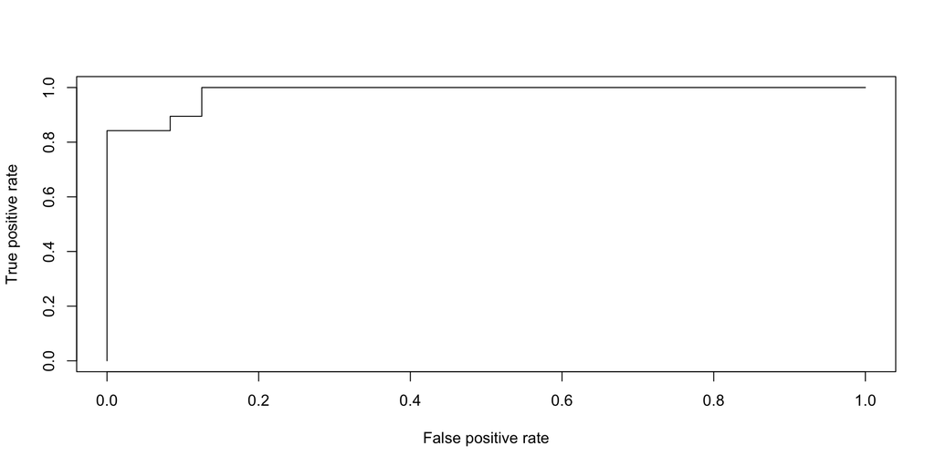

```
#> [1] "AUC"
#> [1] 0.9824561
```

## Support Vector Machine, Utilizing CV Results for Feature Selection

```r
ml_function(CV_subset,"class", "svm")
```

```
#> L2 Regularized Linear Support Vector Machines with Class Weights
#>
#> 99 samples
#> 20 predictors
#>  2 classes: 'DKD', 'normal'
#>
#> No pre-processing
#> Resampling: Cross-Validated (10 fold)
#> Summary of sample sizes: 89, 89, 89, 90, 90, 90, ...
#> Resampling results across tuning parameters:
#>
#>   cost  Loss  weight  Accuracy   Kappa
#>   0.25  L1    1       0.8125253  0.5880020
#>   0.25  L1    2       0.8005051  0.5653083
#>   0.25  L1    3       0.8347475  0.6237888
#>   0.25  L2    1       0.8791919  0.7511430
#>   0.25  L2    2       0.8903030  0.7703738
#>   0.25  L2    3       0.8993939  0.7943564
#>   0.50  L1    1       0.8016162  0.5662362
#>   0.50  L1    2       0.8205051  0.6060983
#>   0.50  L1    3       0.8114141  0.5832584
#>   0.50  L2    1       0.8903030  0.7775166
#>   0.50  L2    2       0.8882828  0.7713483
#>   0.50  L2    3       0.8993939  0.7943564
#>   1.00  L1    1       0.8386869  0.6455226
#>   1.00  L1    2       0.8225253  0.6000916
#>   1.00  L1    3       0.8136364  0.5780498
#>   1.00  L2    1       0.9105051  0.8180515
#>   1.00  L2    2       0.8903030  0.7703738
#>   1.00  L2    3       0.8993939  0.7943564
#>
#> Accuracy was used to select the optimal model using the largest value.
#> The final values used for the model were cost = 1, Loss = L2 and weight = 1.
#> ROC curve variable importance
#>
#>          Importance
#> ALDOB        0.9473
#> IGKC         0.7722
#> DEFA1B       0.7681
#> IGHG2        0.7627
```

[output cut: 28 more lines]

```
#>                   Kappa : 0.4756
#>
#>  Mcnemar's Test P-Value : 0.3428
#>
#>             Sensitivity : 0.7500
#>             Specificity : 0.7742
#>          Pos Pred Value : 0.5625
#>          Neg Pred Value : 0.8889
#>              Prevalence : 0.2791
#>          Detection Rate : 0.2093
#>    Detection Prevalence : 0.3721
#>       Balanced Accuracy : 0.7621
#>
#>        'Positive' Class : DKD
#>
```

## Naive Bayes, Utilizing DE Results for Feature Selection

```r
ml_function(DE_subset,"class", "nb")
```

```
#> Naive Bayes
#>
#> 99 samples
#> 20 predictors
#>  2 classes: 'DKD', 'normal'
#>
#> No pre-processing
#> Resampling: Cross-Validated (10 fold)
#> Summary of sample sizes: 89, 89, 89, 89, 90, 89, ...
#> Resampling results across tuning parameters:
#>
#>   usekernel  Accuracy   Kappa
#>   FALSE      0.9777778  0.9526316
#>    TRUE      0.9477778  0.8926316
#>
#> Tuning parameter 'laplace' was held constant at a value of 0
#> Tuning
#>  parameter 'adjust' was held constant at a value of 1
#> Accuracy was used to select the optimal model using the largest value.
#> The final values used for the model were laplace = 0, usekernel = FALSE
#>  and adjust = 1.
#> ROC curve variable importance
#>
#>           Importance
#> MAL2          0.9254
#> STARD7        0.8191
#> PPP2CB        0.7960
#> ADI1          0.7837
#> DEFA1B        0.7722
#> VCL           0.7449
#> CHCHD2        0.7294
#> TMEM98        0.7163
#> KIDINS220     0.7083
#> GPR182        0.6985
#> LSP1          0.6888
#> CYTIP         0.6765
#> SPATA31A6     0.6737
#> TNFRSF10C     0.6600
#> PFKFB3        0.6485
#> SH2D3A        0.6428
```

[output cut: 16 more lines]

```
#>                   Kappa : 0.9044
#>
#>  Mcnemar's Test P-Value : 1
#>
#>             Sensitivity : 0.9444
#>             Specificity : 0.9600
#>          Pos Pred Value : 0.9444
#>          Neg Pred Value : 0.9600
#>              Prevalence : 0.4186
#>          Detection Rate : 0.3953
#>    Detection Prevalence : 0.4186
#>       Balanced Accuracy : 0.9522
#>
#>        'Positive' Class : DKD
#>
```

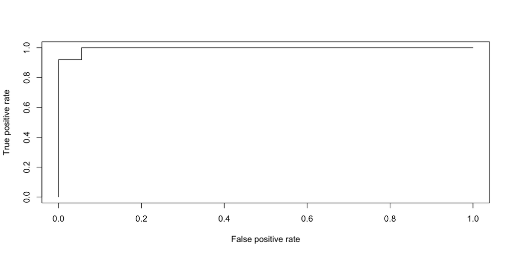

```
#> [1] "AUC"
#> [1] 0.9955556
```

## K-Nearest Neighbor, Utilizing DE Results for Feature Selection

```r
ml_function(DE_subset,"class", "knn")
```

```
#> k-Nearest Neighbors
#>
#> 99 samples
#> 20 predictors
#>  2 classes: 'DKD', 'normal'
#>
#> No pre-processing
#> Resampling: Cross-Validated (10 fold)
#> Summary of sample sizes: 89, 89, 89, 89, 89, 89, ...
#> Resampling results across tuning parameters:
#>
#>   k   Accuracy   Kappa
#>    3  0.9809091  0.9596168
#>    4  0.9609091  0.9196168
#>    5  0.9709091  0.9396168
#>    6  0.9709091  0.9396168
#>    7  0.9709091  0.9396168
#>    8  0.9609091  0.9196168
#>    9  0.9709091  0.9396168
#>   10  0.9709091  0.9396168
#>
#> Accuracy was used to select the optimal model using the largest value.
#> The final value used for the model was k = 3.
#> ROC curve variable importance
#>
#>           Importance
#> MAL2          0.9199
#> STARD7        0.8429
#> PPP2CB        0.8003
#> ADI1          0.7796
#> DEFA1B        0.7498
#> CHCHD2        0.7359
#> VCL           0.7357
#> TMEM98        0.7124
#> KIDINS220     0.7048
#> GPR182        0.6922
#> LSP1          0.6718
#> DHX34         0.6369
#> TNFRSF10C     0.6331
#> SPATA31A6     0.6255
```

[output cut: 18 more lines]

```
#>                   Kappa : 0.9531
#>
#>  Mcnemar's Test P-Value : 1
#>
#>             Sensitivity : 1.0000
#>             Specificity : 0.9583
#>          Pos Pred Value : 0.9500
#>          Neg Pred Value : 1.0000
#>              Prevalence : 0.4419
#>          Detection Rate : 0.4419
#>    Detection Prevalence : 0.4651
#>       Balanced Accuracy : 0.9792
#>
#>        'Positive' Class : DKD
#>
```

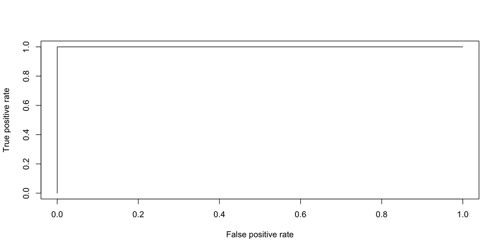

```
#> [1] "AUC"
#> [1] 1
```

## Random Forest, Utilizing DE Results for Feature Selection

```r
ml_function(DE_subset, "class", "rf")
```

```
#> Random Forest
#>
#> 99 samples
#> 20 predictors
#>  2 classes: 'DKD', 'normal'
#>
#> No pre-processing
#> Resampling: Cross-Validated (10 fold)
#> Summary of sample sizes: 89, 89, 89, 89, 90, 89, ...
#> Resampling results across tuning parameters:
#>
#>   mtry  Accuracy   Kappa
#>    2    0.9600000  0.9000000
#>    6    0.9488889  0.8769231
#>   11    0.9388889  0.8569231
#>   15    0.9288889  0.8369231
#>   20    0.8988889  0.7698019
#>
#> Accuracy was used to select the optimal model using the largest value.
#> The final value used for the model was mtry = 2.
#> ROC curve variable importance
#>
#>           Importance
#> MAL2          0.8968
#> PPP2CB        0.8139
#> STARD7        0.8021
#> DEFA1B        0.7544
#> VCL           0.7407
#> CHCHD2        0.7199
#> ADI1          0.7197
#> TMEM98        0.7115
#> KIDINS220     0.7086
#> LSP1          0.6735
#> DHX34         0.6577
#> GPR182        0.6512
#> SPATA31A6     0.6400
#> CD48          0.6280
#> PFKFB3        0.6234
#> TNFRSF10C     0.6169
#> SH2D3A        0.6144
```

[output cut: 15 more lines]

```
#>                   Kappa : 1
#>
#>  Mcnemar's Test P-Value : NA
#>
#>             Sensitivity : 1.0000
#>             Specificity : 1.0000
#>          Pos Pred Value : 1.0000
#>          Neg Pred Value : 1.0000
#>              Prevalence : 0.4419
#>          Detection Rate : 0.4419
#>    Detection Prevalence : 0.4419
#>       Balanced Accuracy : 1.0000
#>
#>        'Positive' Class : DKD
#>
```

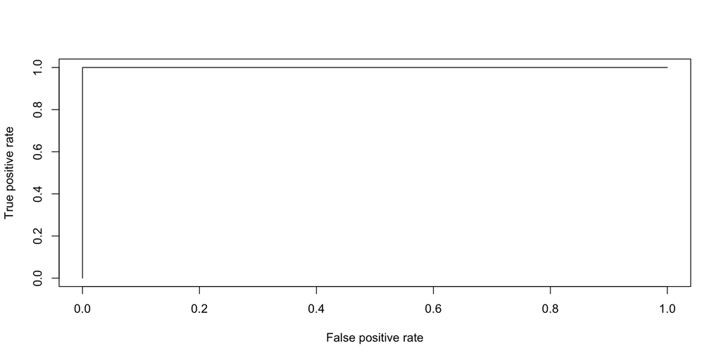

```
#> [1] "AUC"
#> [1] 1
```

## Support Vector Machine, Utilizing DE Results for Feature Selection

```r
ml_function(DE_subset,"class", "svm")
```

```
#> L2 Regularized Linear Support Vector Machines with Class Weights
#>
#> 99 samples
#> 20 predictors
#>  2 classes: 'DKD', 'normal'
#>
#> No pre-processing
#> Resampling: Cross-Validated (10 fold)
#> Summary of sample sizes: 89, 88, 88, 89, 90, 89, ...
#> Resampling results across tuning parameters:
#>
#>   cost  Loss  weight  Accuracy   Kappa
#>   0.25  L1    1       0.9688889  0.9380488
#>   0.25  L1    2       0.9688889  0.9380488
#>   0.25  L1    3       0.9688889  0.9380488
#>   0.25  L2    1       0.9788889  0.9580488
#>   0.25  L2    2       0.9900000  0.9800000
#>   0.25  L2    3       0.9900000  0.9800000
#>   0.50  L1    1       0.9688889  0.9380488
#>   0.50  L1    2       0.9688889  0.9380488
#>   0.50  L1    3       0.9688889  0.9380488
#>   0.50  L2    1       0.9788889  0.9580488
#>   0.50  L2    2       0.9900000  0.9800000
#>   0.50  L2    3       0.9900000  0.9800000
#>   1.00  L1    1       0.9688889  0.9380488
#>   1.00  L1    2       0.9688889  0.9380488
#>   1.00  L1    3       0.9688889  0.9380488
#>   1.00  L2    1       0.9788889  0.9580488
#>   1.00  L2    2       0.9900000  0.9800000
#>   1.00  L2    3       0.9900000  0.9800000
#>
#> Accuracy was used to select the optimal model using the largest value.
#> The final values used for the model were cost = 0.25, Loss = L2 and weight = 2.
#> ROC curve variable importance
#>
#>           Importance
#> MAL2          0.9120
#> STARD7        0.8310
#> PPP2CB        0.8138
#> ADI1          0.7678
```

[output cut: 28 more lines]

```
#>                   Kappa : 1
#>
#>  Mcnemar's Test P-Value : NA
#>
#>             Sensitivity : 1.0000
#>             Specificity : 1.0000
#>          Pos Pred Value : 1.0000
#>          Neg Pred Value : 1.0000
#>              Prevalence : 0.5814
#>          Detection Rate : 0.5814
#>    Detection Prevalence : 0.5814
#>       Balanced Accuracy : 1.0000
#>
#>        'Positive' Class : DKD
#>
```